# TFG-Visualizacion-MNIST

```
                        Aprendizaje No-supervisado con Modelos Generativos Profundos

                                        Fernando Arribas Jara

                                    TUTOR: Daniel Hernández Lobato

                                    UNIVERSIDAD AUTONOMA DE MADRID
```

Auto-Encoding Variational Bayes

[figure not shown]

Se usa una distribucion Normal MLP (Multilayer perceptron) como encoder(Apendice C: C-2 https://arxiv.org/pdf/1312.6114.pdf)

Se usa una distribucion de Bernoulli MLP como decoder(Apendice C: C-1 https://arxiv.org/pdf/1312.6114.pdf)

Como funciones de activación se han usado:

```
Rectificación Lineal (RELU): Encoder y en el Decoder en su primera capa

Sigmoide: decoder en su capa de salida

Exponencial: Salida de las varianzas
```

Para inicializar las variables me he basado en este paper, concretamente la seccion 4.6. http://yann.lecun.com/exdb/publis/pdf/lecun-98b.pdf que dice:

[figure not shown]

También he usado este paper para elegir las funciones de activación.

Como funcion de activación en la capa de salida he usado una funcion sigmoide para que los pixeles valan o bién 0 o 1.

El objetivo es maximizar el ELBO en esta expresión para asi hacer muy pequeña la divergencia KL entre las dos distribuciones que queremos aproximar (Back box varitional inference: https://arxiv.org/pdf/1401.0118.pdf) y por consiguiente mejorar Log P(x):

\begin{equation*} \log(P_{\Theta}(x^{i})) = D_KL(q_{\Phi}(z|x^{i}) || p_{\Theta}(z|x^{i})) + \underbrace{\mathscr{L}(\Theta, \Phi; x^{i})}_{ELBO} \end{equation*}

Dos redes neuronales

1) Encoder: Queremos inferir P(z|x) usando \begin{equation*} Q(z|x, \Phi) \end{equation*}

Nos devuelve una media y una varianza por cada dimension.

2) Muestreo de z

Realizamos el muestreo sabiendo que \begin{equation*} X \sim \mathcal{N}(\mu,\,\sigma^{2})\ \end{equation*} Posteriormente aplicamos el truco de la re-parametrizacion para sacar fuera de la red todo lo que no es diferenciable y poder calcular el gradiente por retropropagación. \begin{equation*} z = \mu + exp(\sigma^{2}/2)*\in \end{equation*}

NOTA: Cogemos \begin{equation*} \log(\sigma^{2}) \end{equation*} porque se ha demostrado que es mejor usar exp en lugar de log ya que es numericamente más estable.Esto se usa tanto aqui como a la hora de calcular la divergencia KL.He probado ambas formas y tomando log se obtienen mejores resultados

3) Decoder: \begin{equation*} P(x|z, \Theta) \end{equation*}

Generación de datos dada la variable latente z

CODIGO

Importo modulos necesarios y evito warning molestos

```python
import os
os.environ['TF_CPP_MIN_LOG_LEVEL']='2'
import tensorflow as tf
import numpy as np
import matplotlib.pyplot as plt
%matplotlib inline
import time
from tensorflow.examples.tutorials.mnist import input_data
```

Importar dataset MNIST

```python
mnist = input_data.read_data_sets("MNIST_data", one_hot=True)
```

```
Extracting MNIST_data\train-images-idx3-ubyte.gz
Extracting MNIST_data\train-labels-idx1-ubyte.gz
Extracting MNIST_data\t10k-images-idx3-ubyte.gz
Extracting MNIST_data\t10k-labels-idx1-ubyte.gz
```

Creo las varibles con los parametros de configuración del modelo

```python
#Variables de Train
num_epocas =50
batch_size = 100
learning_rate = 1e-3
n_datos = mnist.train.num_examples
num_batch = int(n_datos / batch_size)
#Variables del dataset
tam_imagen = 784 # Imagenes de 28x28 pixels
tam_latente = 2
tam_hidden_layer = 700
```

# Creo las variables de entrada del modelo (Input -> Imagenes)

```python
x = tf.placeholder(tf.float32, shape=[None, tam_imagen]) #Entrada de datos, imagenes
```

MODELO

Primera capa: ENCODER

```python
#Semilla aleatoria
tf.set_random_seed(0)
#Pesos y biases
#Primera capa oculta
W_encoder1 = tf.Variable(tf.random_normal([tam_imagen, tam_hidden_layer], stddev= tf.pow(float(tam_imagen), -0.5)))
b_encoder1 = tf.Variable(tf.random_normal([tam_hidden_layer], stddev= tf.pow(float(tam_hidden_layer), -0.5)))

#Segunda capa: salida encoder
W_encoder_out = tf.Variable(tf.random_normal([tam_hidden_layer, tam_hidden_layer], stddev= tf.pow(float(tam_hidden_layer), -0.5)))
b_encoder_out = tf.Variable(tf.random_normal([tam_hidden_layer], stddev= tf.pow(float(tam_hidden_layer), -0.5)))

W_z_var = tf.Variable(tf.random_normal([tam_hidden_layer,tam_latente], stddev=tf.pow(float(tam_hidden_layer), -0.5)))
b_z_var = tf.Variable(tf.random_normal([tam_latente], stddev=tf.pow(float(tam_latente), -0.5)))

W_z_mean = tf.Variable(tf.random_normal([tam_hidden_layer,tam_latente], stddev=tf.pow(float(tam_hidden_layer), -0.5)))
b_z_mean = tf.Variable(tf.random_normal([tam_latente], stddev=tf.pow(float(tam_latente), -0.5)))

#Model del Encoder
encoder_capa1 = tf.matmul(x, W_encoder1) + b_encoder1
encoder_capa1 = tf.nn.relu(encoder_capa1)
encoder_out = tf.matmul(encoder_capa1, W_encoder_out) + b_encoder_out
encoder_out = tf.nn.relu(encoder_out)
```

Segunda capa: Muestreo de Z

```python
#Mean
z_mean = tf.matmul(encoder_out,W_z_mean)+b_z_mean
#Std
z_var = tf.matmul(encoder_out, W_z_var)+b_z_var

epsilon = tf.random_normal(tf.shape(z_mean),mean=0.0,stddev=1.0,dtype=tf.float32)
z = z_mean + (tf.multiply(tf.sqrt(tf.exp(z_var)),epsilon))
```

Tercera capa: DECODER

```python
#Pesos y biases
#Primera capa oculta
W_decoder1 = tf.Variable(tf.random_normal([tam_latente, tam_hidden_layer], stddev=tf.pow(float(tam_latente), -0.5)))
b_decoder1 = tf.Variable(tf.random_normal([tam_hidden_layer], stddev= tf.pow(float(tam_hidden_layer), -0.5)))

#Segunda capa oculta
W_decoder2 = tf.Variable(tf.random_normal([tam_hidden_layer, tam_hidden_layer], stddev= tf.pow(float(tam_hidden_layer), -0.5)))
b_decoder2 = tf.Variable(tf.random_normal([tam_hidden_layer], stddev= tf.pow(float(tam_hidden_layer), -0.5)))

W_decoder_out = tf.Variable(tf.random_normal([tam_hidden_layer, tam_imagen], stddev=tf.pow(float(tam_hidden_layer), -0.5)))
b_decoder_out = tf.Variable(tf.random_normal([tam_imagen], stddev= tf.pow(float(tam_imagen), -0.5)))

#Model del Decoder
decoder_capa1 = tf.matmul(z, W_decoder1) + b_decoder1
decoder_capa1 = tf.nn.relu(decoder_capa1)
decoder_capa2 = tf.matmul(decoder_capa1, W_decoder2) + b_decoder2
decoder_capa2 = tf.nn.relu(decoder_capa2)
decoder_out = tf.matmul(decoder_capa2, W_decoder_out) + b_decoder_out
decoder_out = tf.nn.sigmoid(decoder_out)
```

ELBO

\begin{equation*} \underbrace{\mathscr{L}(\Theta, \Phi; x^{i})}_{ELBO} = -D_KL(q_{\Phi}(z|x^{i}) || p_{\Theta}(z|x^{i})) + \log(P_{\Theta}(x^{i})) \end{equation*}

Donde:  
\begin{equation*} -D_KL(q_{\Phi}(z|x^{i}) || p_{\Theta}(z|x^{i})) = \frac{1}{2}\sum_{j=1}^J (1 + \log(\sigma_{j}^2) - \mu_{j}^2 - \sigma_{j}^2) \end{equation*}

\begin{equation*} \log(p(x|z)) = \sum_{i=1}^D x_{i}logy_{i} + (1- x_{i}). log(1-y_{i}) \end{equation*}

Nota:

En la divergencia KL usamos \begin{equation*} \log(\sigma^{2}) \end{equation*} porque se ha demostrado que es mejor usar exp en lugar de log ya que es numericamente más estable.

En cambio en la expresión \begin{equation*} \log(p(x|z)) \end{equation*} no es posible de ahí que se defina un min y un max (tf.clip_by_value) para evitar evaluar un log(0) que daria error.

```python
#Para evitar que que el calculo de gradientes de error cuando los logaritmos son log(x) con x~0 se suma un sesgo  1e-9
decoder_out = tf.clip_by_value(decoder_out, 1e-9, 1 - 1e-9)
likelihood = tf.reduce_sum(x * tf.log(decoder_out) + (1 - x) * tf.log(1 - decoder_out), 1)
#Divergencia KL:  -D_KL(q(z)||p(z))
KL = (1/2) * tf.reduce_sum(1 + z_var - tf.square(z_mean) - tf.exp(z_var), 1)

#El likelihood se escala al tam de los batches
ELBO =  tf.reduce_mean(KL + likelihood)
```

Funcion de coste en la que maximizamos el ELBO

```python
#Como nuestro objetivo es maximizar el ELBO vamos en sentido positivo al gradiente
function_coste = -ELBO
```

Optimizador Adam (https://arxiv.org/pdf/1412.6980.pdf)

```python
optimizer = tf.train.AdamOptimizer(learning_rate = learning_rate, beta1 = 0.9, beta2 = 0.999, epsilon = 1e-08)
train_step = optimizer.minimize(function_coste)
```

ENTRENAMIENTO

Proceso de aprendizaje

```python
def generador(epoca,ejemplos_test):
        decoder_capa1 = tf.matmul(z, W_decoder1) + b_decoder1
        decoder_capa1 = tf.nn.relu(decoder_capa1)
        decoder_capa2 = tf.matmul(decoder_capa1, W_decoder2) + b_decoder2
        decoder_capa2 = tf.nn.relu(decoder_capa2)
        decoder_out = tf.matmul(decoder_capa2, W_decoder_out) + b_decoder_out
        decoder_out = tf.nn.sigmoid(decoder_out)
        datos = session.run(decoder_out, feed_dict={x: ejemplos_test})
        if(epoca ==0):
            plt.subplot((num_epocas//10) +1,10,1)
            plt.title("Input")
            img = plt.imshow(ejemplos_test[0].reshape(28, 28))
            img.set_cmap('gray')
            plt.axis('off')
            plt.subplot((num_epocas//10) +1,10,2)
            plt.title("    Decoder")
            img = plt.imshow(datos[0].reshape(28, 28))
            img.set_cmap('gray')
            plt.axis('off')
        else:
            plt.subplot((num_epocas//10) +1 ,10,epoca + 2)
            img = plt.imshow(datos[0].reshape(28, 28))
            img.set_cmap('gray')
            plt.axis('off')
```

```
Entrenamiento
Epoca: 1 Tiempo: 28.671966  Loss= 176.987340
Epoca: 2 Tiempo: 24.980136  Loss= 156.019917
Epoca: 3 Tiempo: 24.286751  Loss= 151.538078
Epoca: 4 Tiempo: 24.174037  Loss= 149.183229
Epoca: 5 Tiempo: 24.657955  Loss= 147.306528
Epoca: 6 Tiempo: 24.473038  Loss= 145.947441
Epoca: 7 Tiempo: 24.453204  Loss= 145.070625
Epoca: 8 Tiempo: 24.494392  Loss= 144.224586
Epoca: 9 Tiempo: 24.209020  Loss= 143.496733
Epoca: 10 Tiempo: 24.737382  Loss= 142.760638
Epoca: 11 Tiempo: 24.590083  Loss= 142.096468
Epoca: 12 Tiempo: 25.359022  Loss= 141.453599
Epoca: 13 Tiempo: 24.860666  Loss= 141.183551
Epoca: 14 Tiempo: 24.342194  Loss= 140.834380
Epoca: 15 Tiempo: 24.517017  Loss= 140.573511
Epoca: 16 Tiempo: 24.917783  Loss= 140.260801
Epoca: 17 Tiempo: 24.228405  Loss= 139.870785
Epoca: 18 Tiempo: 24.602550  Loss= 139.296412
Epoca: 19 Tiempo: 24.870496  Loss= 139.077469
Epoca: 20 Tiempo: 24.955560  Loss= 138.970781
Epoca: 21 Tiempo: 25.273022  Loss= 138.695019
Epoca: 22 Tiempo: 24.443785  Loss= 138.409254
Epoca: 23 Tiempo: 24.616567  Loss= 138.414931
Epoca: 24 Tiempo: 24.477179  Loss= 138.166926
Epoca: 25 Tiempo: 24.421392  Loss= 138.177162
Epoca: 26 Tiempo: 24.625099  Loss= 138.003617
Epoca: 27 Tiempo: 24.421828  Loss= 137.808210
Epoca: 28 Tiempo: 24.266127  Loss= 137.509626
Epoca: 29 Tiempo: 24.703861  Loss= 137.421836
Epoca: 30 Tiempo: 24.337520  Loss= 137.343441
Epoca: 31 Tiempo: 24.504182  Loss= 137.225481
Epoca: 32 Tiempo: 24.422967  Loss= 136.920017
Epoca: 33 Tiempo: 24.245071  Loss= 136.889062
Epoca: 34 Tiempo: 24.556031  Loss= 136.786148
Epoca: 35 Tiempo: 24.608131  Loss= 136.385964
Epoca: 36 Tiempo: 24.354127  Loss= 136.606978
Epoca: 37 Tiempo: 24.976454  Loss= 136.203550
Epoca: 38 Tiempo: 24.330282  Loss= 136.073264
Epoca: 39 Tiempo: 24.570495  Loss= 136.064363
Epoca: 40 Tiempo: 24.645113  Loss= 136.224668
Epoca: 41 Tiempo: 24.266798  Loss= 135.615957
Epoca: 42 Tiempo: 24.549530  Loss= 135.567244
Epoca: 43 Tiempo: 24.969060  Loss= 135.606430
Epoca: 44 Tiempo: 24.272809  Loss= 135.450793
Epoca: 45 Tiempo: 24.884603  Loss= 135.412196
Epoca: 46 Tiempo: 24.283148  Loss= 135.316442
Epoca: 47 Tiempo: 24.745416  Loss= 135.668108
Epoca: 48 Tiempo: 24.448437  Loss= 135.473734
Epoca: 49 Tiempo: 24.255927  Loss= 134.924011
Epoca: 50 Tiempo: 24.759954  Loss= 134.983714

Test con 2-D latentes, Numero de epocas 50, Tasa de Aprendizaje 0.001000  y Tam Capas Ocultas 700

DECODIFICACION

Input
```

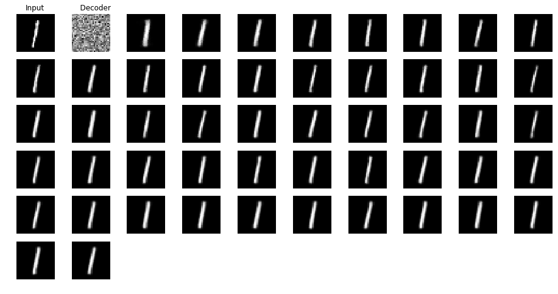

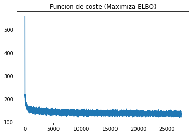

```python
print('Entrenamiento')
session = tf.InteractiveSession()
tf.global_variables_initializer().run()
valores_coste = []
ejemplos_test,_ = mnist.test.next_batch(batch_size)
plt.figure(figsize=(16, 8))
generador(0,ejemplos_test)
num_col = 1
for epoca in range(1, num_epocas+1):
    average_coste = 0
    inicio = time.time()
    for i in range(num_batch):
        batch, _ = mnist.train.next_batch(batch_size)
        _, coste = session.run([train_step, function_coste], feed_dict = {x: batch} )
        average_coste = (average_coste + coste)
        valores_coste.append(coste)
    fin = time.time()
    tiempo = fin - inicio
    print('Epoca: %d Tiempo: %f  Loss= %f' % (epoca,tiempo,average_coste/num_batch))
    generador(num_col,ejemplos_test)
    num_col += 1


print('\nTest con %d-D latentes, Numero de epocas %d, Tasa de Aprendizaje %f  y Tam Capas Ocultas %d' % (tam_latente, num_epocas,learning_rate,tam_hidden_layer))
print ("\nDECODIFICACION")
print ("\nInput")
plt.figure()
plt.title("Funcion de coste (Maximiza ELBO)")
plt.plot(valores_coste)
plt.show()
```

Visualización

Espacio latente

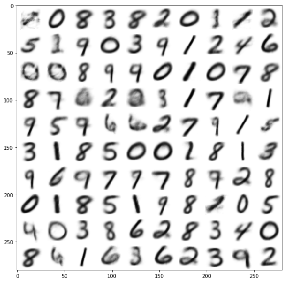

```python
n = 10
input_decoder_2d = tf.placeholder(tf.float32, shape=[None, tam_latente])
canvas = np.empty((28*n, 28*n))
for i in range(n):
    for j in range(n):
        decoder_capa1 = tf.matmul(input_decoder_2d, W_decoder1) + b_decoder1
        decoder_capa1 = tf.nn.relu(decoder_capa1)
        decoder_capa2 = tf.matmul(decoder_capa1, W_decoder2) + b_decoder2
        decoder_capa2 = tf.nn.relu(decoder_capa2)
        decoder_out = tf.matmul(decoder_capa2, W_decoder_out) + b_decoder_out
        decoder_out = tf.nn.sigmoid(decoder_out)
        imagenes_generadas = session.run(decoder_out, feed_dict={input_decoder_2d: np.random.randn(50, tam_latente)})
        canvas[(n-i-1)*28:(n-i)*28, j*28:(j+1)*28] = imagenes_generadas[np.random.randint(0, 49)].reshape(28, 28)

plt.figure(figsize=(8, 10))
plt.imshow(canvas,cmap="binary", origin="upper")
plt.tight_layout()
```

Dispersión del espacio latente de 2D mostrado en 2-D

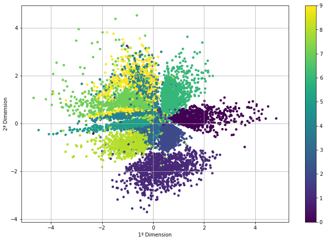

```python
input_image, target = mnist.test.next_batch(mnist.test.num_examples)
input_encoder_2d = tf.placeholder(tf.float32, shape=[None, tam_imagen])
encoder_capa1 = tf.matmul(input_encoder_2d, W_encoder1) + b_encoder1
encoder_capa1 = tf.nn.relu(encoder_capa1)
encoder_out = tf.matmul(encoder_capa1, W_encoder_out) + b_encoder_out
encoder_out = tf.nn.relu(encoder_out)
encoder = session.run(encoder_out, feed_dict={input_encoder_2d: input_image})
z_mean =tf.matmul(encoder,W_z_mean)+b_z_mean
mean = session.run(z_mean, feed_dict={input_encoder_2d: input_image})
colores= []
for i in target:
    indice = np.where(i == 1)
    colores.append(indice[0][0])

plt.figure(figsize=(12, 8))
plt.scatter(mean[:, 0], mean[:, 1], s = 15, c=colores)
plt.xlabel('1ª Dimension')
plt.ylabel('2ª Dimension')
plt.colorbar()
plt.grid()
```

Dispersión del espacio latente de 2D mostrado en 3-D

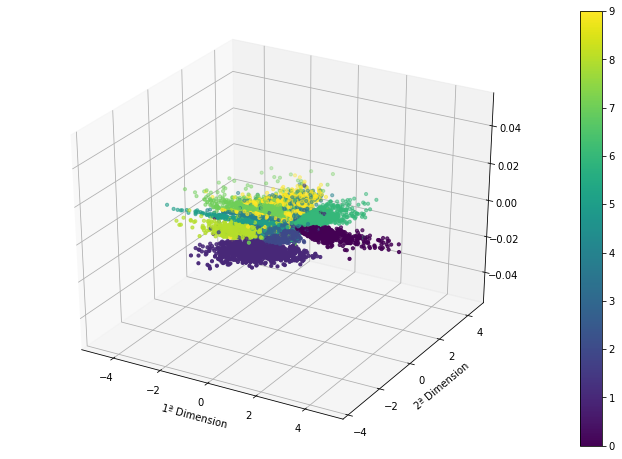

```python
%matplotlib inline
from mpl_toolkits.mplot3d import axes3d
input_image, target = mnist.test.next_batch(mnist.test.num_examples)
input_encoder_3d = tf.placeholder(tf.float32, shape=[None, tam_imagen])
encoder_capa1 = tf.matmul(input_encoder_3d, W_encoder1) + b_encoder1
encoder_capa1 = tf.nn.relu(encoder_capa1)
encoder_out = tf.matmul(encoder_capa1, W_encoder_out) + b_encoder_out
encoder_out = tf.nn.relu(encoder_out)
encoder = session.run(encoder_out, feed_dict={input_encoder_3d: input_image})
z_mean =tf.matmul(encoder,W_z_mean)+b_z_mean
mean = session.run(z_mean, feed_dict={input_encoder_3d: input_image})
fig = plt.figure(figsize=(12, 8))
ax = fig.add_subplot(111, projection='3d')
colores= []
for i in target:
    indice = np.where(i == 1)
    colores.append(indice[0][0])

plt.scatter(mean[:, 0], mean[:, 1], s = 10 ,c=colores)
plt.xlabel('1ª Dimension')
plt.ylabel('2ª Dimension')
plt.autoscale(enable=True, axis='both', tight=None)
plt.colorbar()
plt.grid()
```

Manifold MNIST

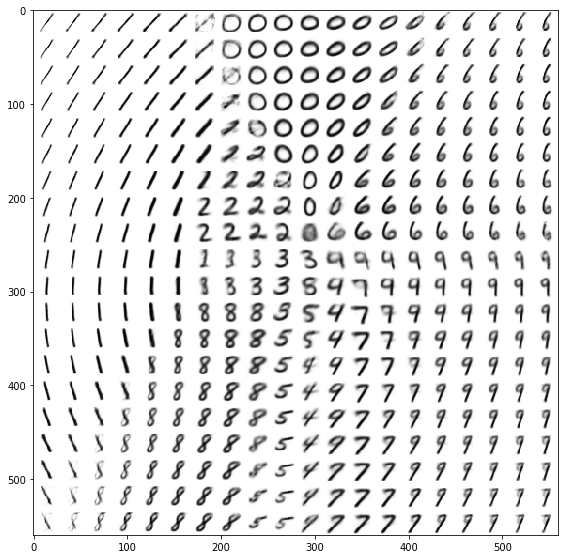

```python
n = 20
primera_dim = np.linspace(-3,3, n)
segunda_dim = np.linspace(-3,3, n)
z_test = tf.placeholder(tf.float32, shape=[None, tam_latente])
canvas = np.empty((28*n, 28*n))
for i, primera in enumerate(primera_dim):
    for j, segunda in enumerate(segunda_dim):
        z_mean = np.array([[primera, segunda]]*batch_size)
        decoder_capa1 = tf.matmul(z_test, W_decoder1) + b_decoder1
        decoder_capa1 = tf.nn.relu(decoder_capa1)
        decoder_capa2 = tf.matmul(decoder_capa1, W_decoder2) + b_decoder2
        decoder_capa2 = tf.nn.relu(decoder_capa2)
        decoder_out = tf.matmul(decoder_capa2, W_decoder_out) + b_decoder_out
        decoder_out = tf.nn.sigmoid(decoder_out)
        imagenes_generadas = session.run(decoder_out, feed_dict={z_test: z_mean})
        canvas[(n-i-1)*28:(n-i)*28, j*28:(j+1)*28] = imagenes_generadas[0].reshape(28, 28)

plt.figure(figsize=(8, 10))
Xi, Yi = np.meshgrid(primera_dim, segunda_dim)
plt.imshow(canvas,cmap="binary", origin="upper")
plt.tight_layout()
```

2-D Latente Interactivo

```python
%matplotlib inline
from ipywidgets import interactive, Layout

z_test = tf.placeholder(tf.float32, shape=[None, tam_latente])
def generador(primera_dimension, segunda_dimension):
    ejemplo = np.array([[primera_dimension, segunda_dimension]]*batch_size)
    decoder_capa1 = tf.matmul(z_test, W_decoder1) + b_decoder1
    decoder_capa1 = tf.nn.relu(decoder_capa1)
    decoder_capa2 = tf.matmul(decoder_capa1, W_decoder2) + b_decoder2
    decoder_capa2 = tf.nn.relu(decoder_capa2)
    decoder_out = tf.matmul(decoder_capa2, W_decoder_out) + b_decoder_out
    decoder_out = tf.nn.sigmoid(decoder_out)
    imagenes_generadas = session.run(decoder_out, feed_dict={z_test: ejemplo})
    imagen = imagenes_generadas[0].reshape(28, 28)
    plt.figure(figsize=(8, 8))
    ax = plt.subplot(111)
    ax.imshow(imagen, cmap="binary")
    plt.axis("off")

plot = interactive(generador, primera_dimension=(-3, 3,0.01), segunda_dimension=(-3, 3, 0.01))
output = plot.children[0]
output.layout.width = '600px'
output.description='Primera dimension'
output.style = {'description_width': 'initial'}
output = plot.children[1]
output.layout.width = '600px'
output.description='Segunda dimension'
output.style = {'description_width': 'initial'}
plot
```

Ejemplos aleatorios con diferentes dimensiones latentes

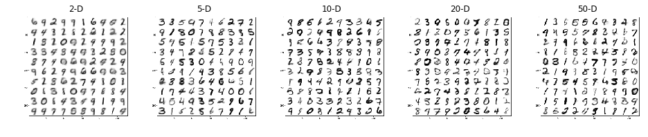

```python
import matplotlib.image as mpimg
plt.figure(figsize=(16, 8))
plt.subplot(1,5,1)
plt.title("2-D")
img=mpimg.imread('2D_Espacio_Latente.png')
img = plt.imshow(img)
img.set_cmap('gray')
plt.axis('off')
plt.subplot(1,5,2)
plt.title("5-D")
img=mpimg.imread('5D_Espacio_Latente.png')
img = plt.imshow(img)
img.set_cmap('gray')
plt.axis('off')
plt.subplot(1,5,3)
plt.title("10-D")
img=mpimg.imread('10D_Espacio_Latente.png')
img = plt.imshow(img)
img.set_cmap('gray')
plt.axis('off')
plt.subplot(1,5,4)
plt.title("20-D")
img=mpimg.imread('20D_Espacio_Latente.png')
img = plt.imshow(img)
img.set_cmap('gray')
plt.axis('off')
plt.subplot(1,5,5)
plt.title("50-D")
img=mpimg.imread('50D_Espacio_Latente.png')
img = plt.imshow(img)
img.set_cmap('gray')
plt.axis('off')
plt.show()
```